# CP05: Colgate Vs Crest

Gonzalo Rodríguez

2020-11-23

# Objetivo

El objetivo es predecir las 16 semanas del año 1963, para las dos cuotas de mercado, por lo que se dejará fuera de la muestra este periodo muestral.

El análisis debe incluir para las dos series la estimación de un modelo ARIMA, la detección de atípicos/outlier y un modelo de interveción. Por último se debe realizar un modelo de función de tranferencia entre las dos cuotas.

## Carga de datos y librerías

## Breve EDA

```r
skim(df)
```

Data summary

| Name | df |
| --- | --- |
| Number of rows | 276 |
| Number of columns | 5 |
| _______________________ |  |
| Column type frequency: |  |
| Date | 1 |
| numeric | 4 |
| ________________________ |  |
| Group variables | None |

**Variable type: Date**

| skim_variable | n_missing | complete_rate | min | max | median | n_unique |
| --- | --- | --- | --- | --- | --- | --- |
| Fecha | 0 | 1 | 1958-01-06 | 1963-04-22 | 1960-08-25 | 276 |

**Variable type: numeric**

| skim_variable | n_missing | complete_rate | mean | sd | p0 | p25 | p50 | p75 | p100 | hist |
| --- | --- | --- | --- | --- | --- | --- | --- | --- | --- | --- |
| Year | 0 | 1 | 1960.17 | 1.54 | 1958.00 | 1959.00 | 1960.00 | 1961.00 | 1963.00 | ▇▃▃▃▁ |
| Week | 0 | 1 | 25.46 | 15.23 | 1.00 | 12.00 | 25.00 | 39.00 | 52.00 | ▇▇▆▆▇ |
| Crest | 0 | 1 | 0.26 | 0.13 | 0.05 | 0.13 | 0.25 | 0.37 | 0.53 | ▇▅▃▇▂ |
| Colgate | 0 | 1 | 0.31 | 0.07 | 0.16 | 0.26 | 0.31 | 0.36 | 0.50 | ▂▇▇▅▁ |

# Formato zoo y graficamos

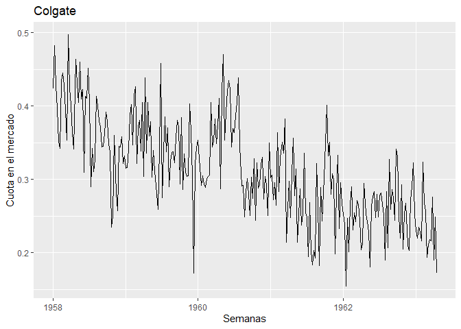

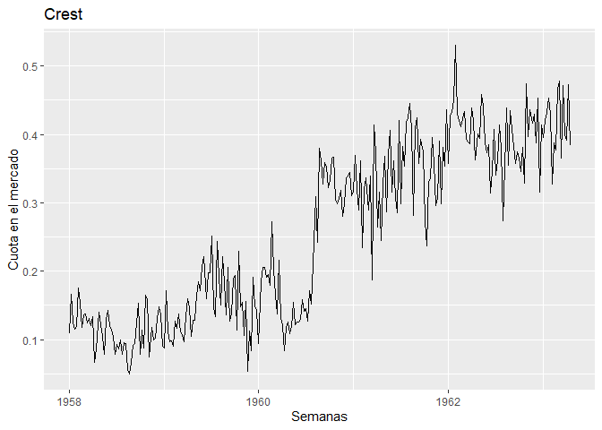

# Creamos la submuestra

Quitamos las 16 semanas correspondientes a 1963.

# Modelo ARIMA

Los conjuntos de datos de series cronológicas pueden contener tendencias y estacionalidad, que tal vez sea necesario eliminar antes de la elaboración de modelos.

Las tendencias pueden dar lugar a una media variable a lo largo del tiempo, mientras que la estacionalidad puede dar lugar a una variación cambiante a lo largo del tiempo, lo que define a una serie temporal como no estacionaria.

Los conjuntos de datos estacionarios son los que tienen una media y una varianza estables, y a su vez son mucho más fáciles de modelar. Por ello, vamos a hacer nuestras series estacionarias.

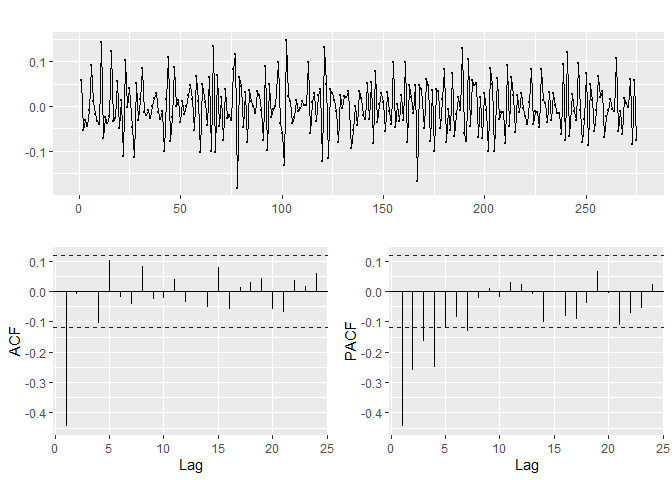

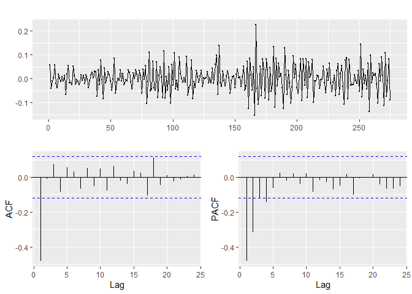

Especificamos el modelo Arima, indicando que queremos que se trabaje sin lambda ya que la varianza es más o menos cte, que nos indica que se trabaja con el logartimo. Posteriormente, mostramos un resumen del mejor modelo Arima.

## Selección del lambda

```r
fit<-auto.arima(oColgate)
summary(fit)
```

```
## Series: oColgate
## ARIMA(0,1,1)(1,0,0)[52]
##
## Coefficients:
##           ma1    sar1
##       -0.7571  0.0232
## s.e.   0.0470  0.0682
##
## sigma^2 estimated as 0.00232:  log likelihood=418.63
## AIC=-831.25   AICc=-831.16   BIC=-820.58
##
## Training set error measures:
##                        ME       RMSE        MAE       MPE     MAPE      MASE
## Training set -0.002534821 0.04788855 0.03773876 -3.019377 12.77398 0.6038201
##                    ACF1
## Training set 0.05216089
```

El modelo ARIMA que se estima para la serie de colgate es en la parte parte regular se ha tenido que aplicar 1 diferencia para hacerlo estacionario y una media móvil de orden 1. Y como parte estacional un autoregresivo de orden 1.

```r
fit1<-auto.arima(oCrest)
summary(fit1)
```

```
## Series: oCrest
## ARIMA(0,1,1)
##
## Coefficients:
##           ma1
##       -0.6494
## s.e.   0.0448
##
## sigma^2 estimated as 0.002054:  log likelihood=434.08
## AIC=-864.15   AICc=-864.1   BIC=-857.04
##
## Training set error measures:
##                       ME       RMSE        MAE       MPE     MAPE      MASE
## Training set 0.003018071 0.04514444 0.03445351 -2.924537 17.27068 0.3800355
##                     ACF1
## Training set -0.04605961
```

El modelo ARIMA que se estima para la serie de Crest es en la parte parte regular se ha tenido que aplicar 1 diferencia para hacerlo estacionario y una media móvil de orden 1. Y sin estructura en la parte estacional.

## Graficamos los residuos.

Nos interesa que los errores sean ruido blanco, como se observa gráficamente.

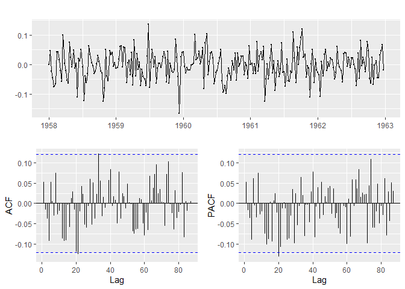

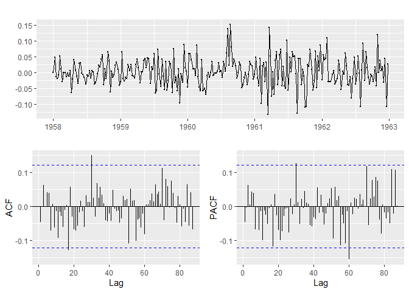

## Análisis de los residuos

| P-value Arima Crest | P-value Arima Colgate |
| --- | --- |
| 0.412942 | 0.7414319 |

No rechazamosla hipótesis nula, ya que el p-value es mayor a 0.05 que indica que nuestro error es ruido blanco.

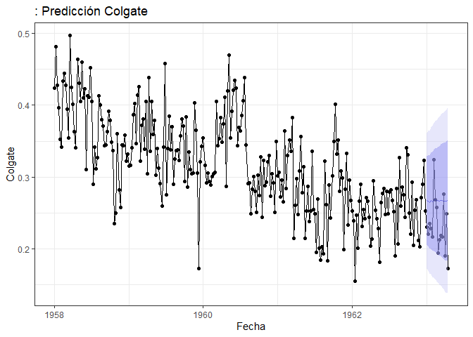

```r
#Predecimos los meses

fColgate.arima<-forecast(fit,h=16)#horizonte de 16 semanas
df_new <- data.frame(value = as.vector(colgateZ), time = time(colgateZ))
ggplot(df_new)+geom_point(aes(x=time,y=value))+geom_line(aes(x=time,y=value))+ geom_forecast(fColgate.arima,alpha=0.4)+xlab("Fecha")+ylab("Colgate")+ggtitle(": Predicción Colgate") + theme_bw()
```

```r
fColgate.arima
```

```
##          Point Forecast     Lo 80     Hi 80     Lo 95     Hi 95
## 1963.000      0.2669631 0.2052343 0.3286919 0.1725571 0.3613692
## 1963.019      0.2666376 0.2031138 0.3301615 0.1694863 0.3637890
## 1963.038      0.2646847 0.1994152 0.3299542 0.1648636 0.3645058
## 1963.058      0.2668236 0.1998539 0.3337933 0.1644023 0.3692449
## 1963.077      0.2657542 0.1971264 0.3343819 0.1607971 0.3707113
## 1963.096      0.2672654 0.1970186 0.3375121 0.1598323 0.3746985
## 1963.115      0.2678234 0.1959942 0.3396525 0.1579701 0.3776766
## 1963.135      0.2664516 0.1930741 0.3398292 0.1542304 0.3786729
## 1963.154      0.2670096 0.1921157 0.3419035 0.1524693 0.3815500
## 1963.173      0.2667074 0.1903272 0.3430875 0.1498940 0.3835207
## 1963.192      0.2673816 0.1895436 0.3452196 0.1483386 0.3864246
## 1963.212      0.2672654 0.1879963 0.3465345 0.1460338 0.3884970
## 1963.231      0.2667539 0.1860791 0.3474287 0.1433725 0.3901353
## 1963.250      0.2658239 0.1837675 0.3478803 0.1403295 0.3913183
## 1963.269      0.2660332 0.1826180 0.3494483 0.1384607 0.3936056
## 1963.288      0.2679396 0.1831875 0.3526917 0.1383225 0.3975567
```

En este gráfico observamos que la línea de color negro es el valor real, mientras que la azul es la predicción , con los intervalos de confianza también en azul. De modo que nos hacemos una idea de la predicción de nuestro modelo. En este caso vemos como se trata de un escalón, donde se recupera la serie original.

[figure not shown]

[output not shown]

En este caso ha una función escalón, que genera un impulso positivo ascendente.

#Outliers

```r
detectAO(fit)
```

```
## [1] "No AO detected"
```

```r
detectAO(fit1)
```

```
##               [,1]       [,2]       [,3]
## ind     135.000000 136.000000 138.000000
## lambda2   3.918954   4.372891   4.005427
```

```r
detectIO(fit)
```

```
## [1] "No IO detected"
```

```r
detectIO(fit1)
```

```
## [1] "No IO detected"
```

#Arimax

- Graficamos el ajuste

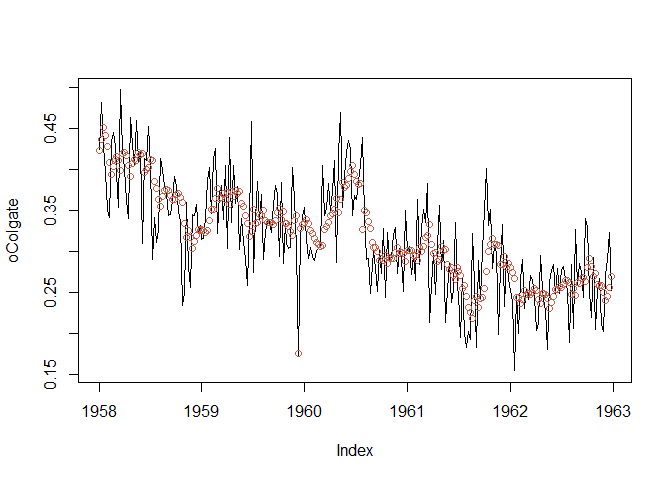

```
##         ma1        sar1       I-MA0       E-AR1       E-MA0
## -0.79262157  0.01307702 -0.06081174  0.04194515 -0.15934980
```

Hacemos el modelo Arimax para crest.

```r
air.crest=arimax(oCrest,order=c(0,1,1),
        xtransf=data.frame(E=1*(seq(oCrest)==137),
            I=1*(seq(oCrest)>=38)),
            xreg=data.frame(o3160=1*(seq(oCrest)==135),
                           o3260=1*(seq(oCrest)==136),
                           o0562=1*(seq(oCrest)==138)),

        transfer=list(c(0,0),c(1,0)),
method='ML')
```

- Ajustamos el modelo

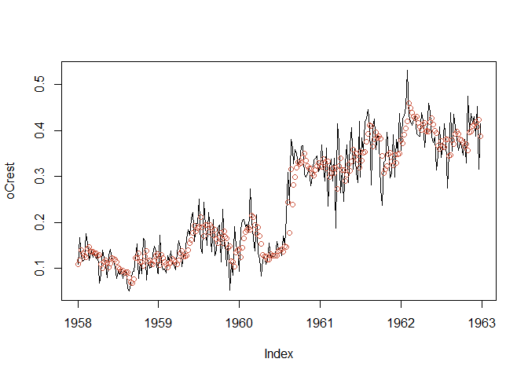

```r
plot(oCrest)
points(fitted(air.crest), col = 'coral3')
```

```r
air.crest$coef
```

```
##           ma1         o3160         o3260         o0562         E-MA0
## -0.6557399802 -0.0037992932  0.0717608483  0.0978459382 -0.0176961771
##         I-AR1         I-MA0
##  0.0002528579  0.0396839943
```

# Función de transferencia

Colgate en función de crest

```r
ftransf <- arimax(oColgate, order=c(0,1,1),                        seasonal=list(order=c(1,0,0),period=52),
               include.mean=TRUE,
               xtransf=oCrest,
               transfer=list(c(0,16)),
               method="ML")
```

Graficamos lo los residuos.

```
##
## Call:
## arimax(x = oColgate, order = c(0, 1, 1), seasonal = list(order = c(1, 0, 0),
##     period = 52), include.mean = TRUE, method = "ML", xtransf = oCrest, transfer = list(c(0,
##     16)))
##
## Coefficients:
##           ma1    sar1  xtransf-MA0  xtransf-MA1  xtransf-MA2  xtransf-MA3
##       -0.8113  0.0175      -0.5068      -0.0450      -0.0281      -0.0210
## s.e.   0.0420  0.0819       0.0572       0.0576       0.0583       0.0588
##       xtransf-MA4  xtransf-MA5  xtransf-MA6  xtransf-MA7  xtransf-MA8
##            0.0940      -0.0243       0.0807       0.0239      -0.0169
## s.e.       0.0591       0.0591       0.0594       0.0593       0.0593
##       xtransf-MA9  xtransf-MA10  xtransf-MA11  xtransf-MA12  xtransf-MA13
##           -0.0069       -0.0418        0.0212       -0.0015        0.0669
## s.e.       0.0604        0.0602        0.0605        0.0620        0.0603
##       xtransf-MA14  xtransf-MA15  xtransf-MA16
##             0.0236       -0.0586        0.0424
## s.e.        0.0594        0.0592        0.0584
##
## sigma^2 estimated as 0.001629:  log likelihood = 434.63,  aic = -831.25
##
## Training set error measures:
##                        ME       RMSE        MAE      MPE     MAPE      MASE
## Training set -0.001439461 0.04028327 0.03100868 -2.01644 10.54429 0.6644534
##                    ACF1
## Training set 0.06955994
```

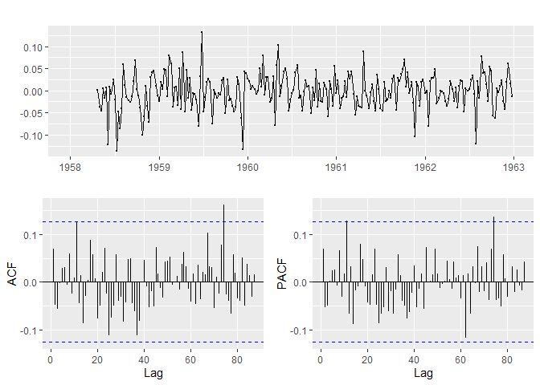

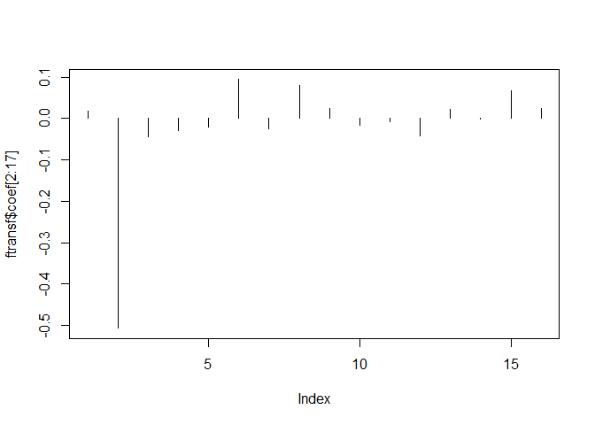